# Ford GoBike

## by Oliver Garcia

## Investigation Overview

> This analysis will determine the minimum number of bikes and where should they be located around the city so every potential user can find an available bike no further than a 100 yards.

> With these results the cost can be controlled by not deploying more bikes than needed but offering enough bikes around the city for the current demand while maintaining a reasonable distance between potential users and idle bikes.

## Dataset Overview

> The data analyzed is from January, February and March of 2019 and was downloaded from https://s3.amazonaws.com/fordgobike-data/index.html. This data contains some basic information about the user like gender but the relevant information for the analysis that this data provides is where a bike was rented, when the bike was rented and the duration of the rental.

## Customer gender distribution

The following charts show that male customers account for almost 3/4 of all customers indicating that females are not as interested in this service as males. If Ford gobike research why females use this service less than males and make changes based on the results of such investigation then there is a potential increase of 50% in the total number of users (supossing that Ford gobike could atract as many female users as male users).

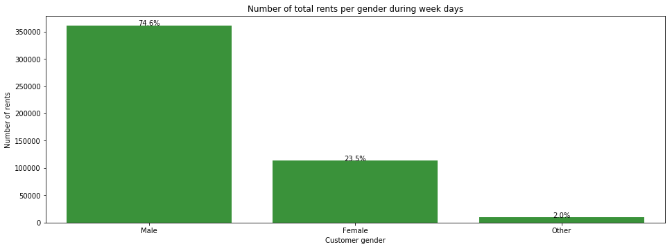

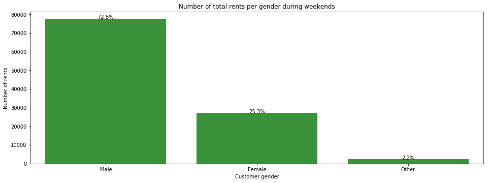

```python
# filtering weekdays only (excluding holidays)
base_color = sb.color_palette()[2]
#print('\033[1m' + 'Customer gender distribution' '\033[0m')
#print('')
#print('These charts show that male customers account for almost 3/4 of all customers indicating that females are not as interested in this service as males. If Ford gobike research why females use this service less than males and make changes based on the results of such investigation then there is a potential increase of 50% in the total number of users (supossing that Ford gobike could atract as many female users as male users).')
gen_order = fordgobike_weekday['member_gender'].value_counts().index
n_customer_weekday = fordgobike_weekday.shape[0]
gen_weekday_count = fordgobike_weekday['member_gender'].value_counts()
# Female vs Male distribution during weekdays
plt.figure(figsize=(16,5.5));
ax = sb.countplot(data = fordgobike_weekday, x = 'member_gender', color = base_color, order = gen_order);
ax.set(xlabel='Customer gender', ylabel='Number of rents', title = 'Number of total rents per gender during week days');

locs, labels = plt.xticks();

# loop through each pair of locations and labels
for loc, label in zip(locs, labels):
    # get the text property for the label to get the correct count
    count = gen_weekday_count[label.get_text()]
    pct_string = '{:0.1f}%'.format(100*count/n_customer_weekday)

    # print the annotation just below the top of the bar
    plt.text(loc, count-8, pct_string, ha = 'center', color = 'black')
n_customer_weekend = fordgobike_weekend.shape[0]
gen_weekend_count = fordgobike_weekend['member_gender'].value_counts()
# Female vs Male distribution during weekdays
plt.figure(figsize=(16,5.5));
ax = sb.countplot(data = fordgobike_weekend, x = 'member_gender', color = base_color, order = gen_order);
ax.set(xlabel='Customer gender', ylabel='Number of rents', title = 'Number of total rents per gender during weekends');

locs, labels = plt.xticks();

# loop through each pair of locations and labels
for loc, label in zip(locs, labels):
    # get the text property for the label to get the correct count
    count = gen_weekend_count[label.get_text()]
    pct_string = '{:0.1f}%'.format(100*count/n_customer_weekend)

    # print the annotation just below the top of the bar
    plt.text(loc, count-8, pct_string, ha = 'center', color = 'black')
```

## Customer user type distribution

More than 80% of users are regular users (subscribers), it is easier to identify patterns of use and preferences in regular customers (subscribers) than random customers (non-subscribers). Finding these patterns or insights can offer an idea on what changes to make on the service or the bikes themselves to better suit the preferences of the subscribers, a more satisfying experience means higher customer loyalty.

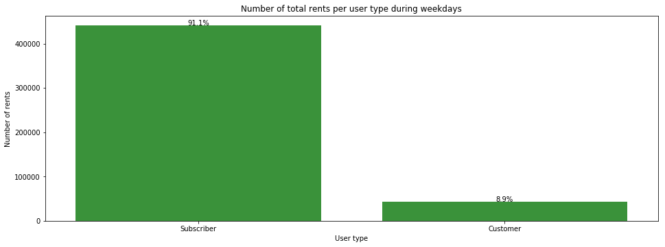

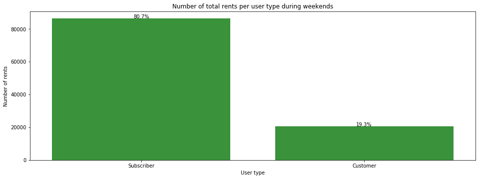

```python
# filtering weekdays only (excluding holidays)
base_color = sb.color_palette()[2]
#print('\033[1m' + 'Customer user type distribution' '\033[0m')
#print('')
#print('More than 80% of users are regular users (subscribers), it is easier to identify patterns of use and preferences in regular customers (subscribers) than random customers (non-subscribers). Finding these patterns or insights can offer an idea on what changes to make on the service or the bikes themselves to better suit the preferences of the subscribers, a more satisfying experience means higher customer loyalty.')
user_type_order = fordgobike_weekday['user_type'].value_counts().index
n_customer_weekday = fordgobike_weekday.shape[0]
user_type_weekday_count = fordgobike_weekday['user_type'].value_counts()
# Customer vs Suscriber distribution during weekdays
plt.figure(figsize=(16,5.5));
ax = sb.countplot(data = fordgobike_weekday, x = 'user_type', color = base_color, order = user_type_order);
ax.set(xlabel='User type', ylabel='Number of rents', title = 'Number of total rents per user type during weekdays');
locs, labels = plt.xticks();

# loop through each pair of locations and labels
for loc, label in zip(locs, labels):
    # get the text property for the label to get the correct count
    count = user_type_weekday_count[label.get_text()]
    pct_string = '{:0.1f}%'.format(100*count/n_customer_weekday)

    # print the annotation just below the top of the bar
    plt.text(loc, count-8, pct_string, ha = 'center', color = 'black')

n_customer_weekend = fordgobike_weekend.shape[0]
user_type_weekend_count = fordgobike_weekend['user_type'].value_counts()
# Customer vs Suscriber distribution during weekdays
plt.figure(figsize=(16,5.5));
ax = sb.countplot(data = fordgobike_weekend, x = 'user_type', color = base_color, order = user_type_order);
ax.set(xlabel='User type', ylabel='Number of rents', title = 'Number of total rents per user type during weekends');
locs, labels = plt.xticks();

# loop through each pair of locations and labels
for loc, label in zip(locs, labels):
    # get the text property for the label to get the correct count
    count = user_type_weekend_count[label.get_text()]
    pct_string = '{:0.1f}%'.format(100*count/n_customer_weekend)

    # print the annotation just below the top of the bar
    plt.text(loc, count-8, pct_string, ha = 'center', color = 'black')
```

#### Rent duration distribution and average rent duration

> The following charts show an strong preferance for short trips of 0.19 hours (11 minutes) during weekdays and 0.27 hours (16 minutes) during weekends.
- The average rental duration during week days is 0.19 hours (11 minutes).
- The average rental duration during weekends is 0.27 hours (16 minutes).
- Because the average rental duration is less than 1 hour we can calculate the aproximate total rental time of all bikes in a given hour as the sum of all rental time in a given hour.
- The aproximation previously mentioned would not work if the average rental time was near or higher than 1 hour.

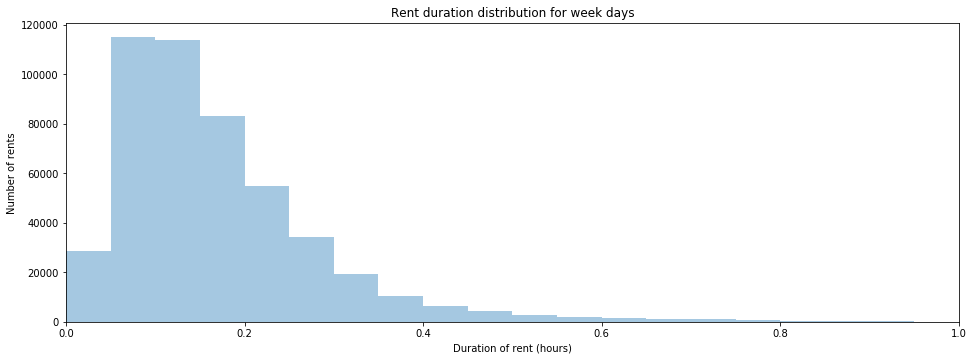

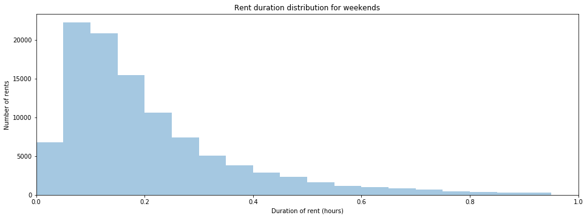

```python
base_color = sb.color_palette()[2]
bins = np.arange(0, 1, 0.05)
plt.figure(figsize=(16,5.5));
plt.xlim(0,1)
average_rental_duration = fordgobike_weekday['duration_hour'].mean()
average_rental_duration_min = round(average_rental_duration*60,0)
# print(f'The average rental duration during week days is \
#{average_rental_duration:.2f} hours ({average_rental_duration_min:.0f} minutes).');
ax = sb.distplot(fordgobike_weekday['duration_hour'],kde = False, bins=bins);
ax.set(xlabel='Duration of rent (hours)', ylabel='Number of rents', title = 'Rent duration distribution for week days');

plt.figure(figsize=(16,5.5));
plt.xlim(0,1)
average_rental_duration = fordgobike_weekend['duration_hour'].mean()
average_rental_duration_min = round(average_rental_duration*60,0)
# print(f'The average rental duration during weekends is \
# {average_rental_duration:.2f} hours ({average_rental_duration_min:.0f} minutes).');
ax = sb.distplot(fordgobike_weekend['duration_hour'],kde = False, bins=bins);
ax.set(xlabel='Duration of rent (hours)', ylabel='Number of rents', title = 'Rent duration distribution for weekends');
```

#### Gender and user type distribution

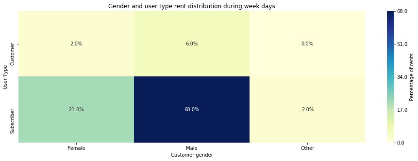

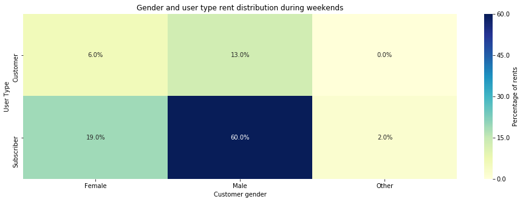

```python
#print('\033[1m' + 'Gender and user type distribution' '\033[0m')
#print('')
#print('These charts reveal some of the same information that we found in the univariate analysis: Male Subscribers account for the majority of users with 61% of all weekend rents and 68% of week days rents.')
# weekday
gender_usertype_weekday = fordgobike_weekday.groupby(['member_gender','user_type'],
                                      as_index=False)['bike_id'].count()
gender_usertype_weekday = gender_usertype_weekday.rename(columns={'bike_id': 'rent_pct'})
gender_usertype_weekday['rent_pct']=round(gender_usertype_weekday['rent_pct']/gender_usertype_weekday['rent_pct'].sum(),2)

# weekend
gender_usertype_weekend = fordgobike_weekend.groupby(['member_gender','user_type'],
                                      as_index=False)['bike_id'].count()
gender_usertype_weekend = gender_usertype_weekend.rename(columns={'bike_id': 'rent_pct'})
gender_usertype_weekend['rent_pct']=round(gender_usertype_weekend['rent_pct']/gender_usertype_weekend['rent_pct'].sum(),2)

result = gender_usertype_weekday.pivot(index='user_type', columns='member_gender', values='rent_pct')
plt.figure(figsize=(16,5));
ax = sb.heatmap(result, cmap="YlGnBu", cbar_kws={'label': 'Percentage of rents'}, annot = result.values, fmt = '.1%',)
ax.set(xlabel='Customer gender', ylabel='User Type', title = 'Gender and user type rent distribution during week days');
cbar = ax.collections[0].colorbar
cbar.set_ticks(np.arange(0, gender_usertype_weekday['rent_pct'].max()+0.01, gender_usertype_weekday['rent_pct'].max()/4))
cbar.set_ticklabels(np.arange(0, 1+(100*gender_usertype_weekday['rent_pct'].max()), 100*gender_usertype_weekday['rent_pct'].max()/4))

result = gender_usertype_weekend.pivot(index='user_type', columns='member_gender', values='rent_pct')
plt.figure(figsize=(16,5));
ax = sb.heatmap(result, cmap="YlGnBu", cbar_kws={'label': 'Percentage of rents'}, annot = result.values, fmt = '.1%',)
ax.set(xlabel='Customer gender', ylabel='User Type', title = 'Gender and user type rent distribution during weekends');
cbar = ax.collections[0].colorbar
cbar.set_ticks(np.arange(0, gender_usertype_weekend['rent_pct'].max()+0.01, gender_usertype_weekend['rent_pct'].max()/4))
cbar.set_ticklabels(np.arange(0, 1+(100*gender_usertype_weekend['rent_pct'].max()), 100*gender_usertype_weekend['rent_pct'].max()/4))
```

## Average total rental time per hour per day

> The following charts show the total rental time per hour defined as the sum of the rent durations for a given hour.
- The busiest hour for weekends is at 2pm with a total of 119.89 hours of rent.
- The weekends total rent time is normally distributed across the whole day.
- The busiest hour for week days is at 5pm with a total of 196.17 hours of rent and there is another busy hour at 8am with a total of 185.76 hours.
- The weekdays total rent time have 2 busy hours at 8am and 5pm, for the rest of the analysis I will focus only on 8am and 5pm of weekdays because those are the hours of highest demand.

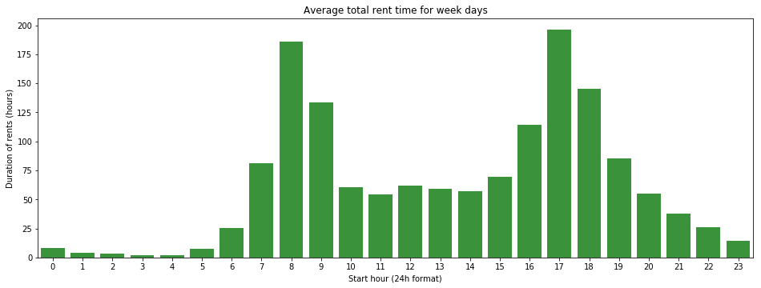

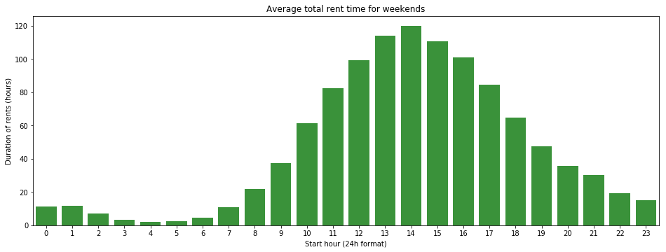

```python
base_color = sb.color_palette()[2]
plt.figure(figsize=(16,5.5));
ax = sb.barplot(data=weekday_usage, x='start_hour', y='duration_hour', color = base_color);
ax.set(xlabel='Start hour (24h format)', ylabel='Duration of rents (hours)', title = 'Average total rent time for week days');
busy_hour_erl = weekday_usage['duration_hour'].max()
erl_8am = weekday_usage['duration_hour'].nlargest(2).min()
# minimum required bikes during busy hour for 1% unavailability
min_required_bikes = erlang.extended_b_lines(busy_hour_erl, 0.001)
#print(f'The busiest hour for week days is at 5pm with a total of {busy_hour_erl:.2f} hours of rent and there is  another busy hour at 8am with a total of {erl_8am:.2f} hours.')

base_color = sb.color_palette()[2]
plt.figure(figsize=(16,5.5));
ax = sb.barplot(data=weekend_usage, x='start_hour', y='duration_hour', color = base_color);
ax.set(xlabel='Start hour (24h format)', ylabel='Duration of rents (hours)', title = 'Average total rent time for weekends');
busy_hour_erl = weekend_usage['duration_hour'].max()
# minimum required bikes during busy hour for 1% unavailability
min_required_bikes = erlang.extended_b_lines(busy_hour_erl, 0.001)
#print(f'The busiest hour for weekends is at 2pm with a total of {busy_hour_erl:.2f} hours of rent.')
```

## Minimun required bikes per location

- The following maps show how many bikes are needed at the busiest hour around the city, this the map has been divided in blocks of 1/8 by 1/8 miles.

```
The total number of bikes required at 8am on weekdays is 1394. The map shows how the bikes should be distributed geographically.
```

[figure not shown]

```python
print(f'The total number of bikes required at 8am on weekdays is {min_required_bikes_8am}. The map shows how the bikes should be distributed geographically.')

fig = plt.figure(figsize=(24, 14))

# Creating map window
m = Basemap(projection='lcc',
            resolution='f',
            lat_0=37.8,
            lon_0=-122.33,
            urcrnrlon=-122.21,
            urcrnrlat=37.89,
            llcrnrlon=-122.46,
            llcrnrlat=37.72,
            epsg = 4326)

# adding title
plt.title("Minimum required bikes per location at 8am on a weekday", fontsize= 20)

# adding streets background image
m.arcgisimage(service='ESRI_StreetMap_World_2D', xpixels = 1000, verbose= False);

# adding grid with number of bikes required
m.scatter(lon,lat, latlon=True,c=bikes,s=100,marker='s',cmap='tab20b', alpha=0.7);

# adding color band legend
plt.colorbar(label=r'Minimum required bikes per location')
plt.clim(0, weekday_8am_loc['min_required_bikes'].max())
```

```
The total number of bikes required at 5pm on weekdays is 1381. The map shows how the bikes should be distributed geographically.
```

[figure not shown]

```python
print(f'The total number of bikes required at 5pm on weekdays is {min_required_bikes_5pm}. The map shows how the bikes should be distributed geographically.')

fig = plt.figure(figsize=(24, 14))

# Creating map window
m = Basemap(projection='lcc',
            resolution='f',
            lat_0=37.8,
            lon_0=-122.33,
            urcrnrlon=-122.21,
            urcrnrlat=37.89,
            llcrnrlon=-122.46,
            llcrnrlat=37.72,
            epsg = 4326)

# adding title
plt.title("Minimum required bikes per location at 5pm on a weekday", fontsize= 20)

# adding streets background image
m.arcgisimage(service='ESRI_StreetMap_World_2D', xpixels = 1000, verbose= False);

# adding grid with number of bikes required
m.scatter(lon,lat, latlon=True,c=bikes,s=100,marker='s',cmap='tab20b', alpha=0.7);

# adding color band legend
plt.colorbar(label=r'Minimum required bikes per location')
plt.clim(0, weekday_5pm_loc['min_required_bikes'].max())
```

- This analysis shows that Ford GoBike requires a minimum of 1394 bikes to assure that a potential user will find a bike no further than 100 yards away 99% of the time. The 8am map and 5pm maps show how many bikes should be in each location during the busiest hours of the day.